# Boosting

Machine Learning

R code for Various Models of Boosting

Yeongeun Jeon , Jeongwook Lee , Jung In Seo  
10-30-2020

> Boosting은 이전 모형의 정보를 이용하여 다음 모형을 순차적으로 생성하는 알고리즘이다. 가장 대표적인 기법은 AdaBoost와 Gradient Boosting이며, 예제 데이터를 이용해 각 기법을 수행해보았다.  
> 예제 데이터는 “Universal Bank_Main”로 유니버셜 은행의 고객들에 대한 데이터(출처 : Data Mining for Business Intelligence, Shmueli et al. 2010)이다. 데이터는 총 2500개이며, 변수의 갯수는 13개이다. 여기서 **Target**은 `Person.Loan`이다.

# **1. 데이터 불러오기**

```
pacman::p_load("data.table", "dplyr")

UB   <- fread(paste(getwd(),"Universal Bank_Main.csv", sep="/")) %>%   # 데이터 불러오기
  data.frame() %>%                                                     # Data frame 변환환
  mutate(Personal.Loan = ifelse(Personal.Loan==1, "yes","no")) %>%     # Character for classification
  select(-1)                                                           # ID변수 제거거



cols <- c("Family", "Education", "Personal.Loan", "Securities.Account",
          "CD.Account", "Online", "CreditCard")

UB   <- UB %>%
  mutate_at(cols, as.factor)                                          # 범주형 변수 변환

glimpse(UB)                                                           # 데이터 구조
```

```
Rows: 2,500
Columns: 13
$ Age                <int> 25, 45, 39, 35, 35, 37, 53, 50, 35, 34, 6~
$ Experience         <int> 1, 19, 15, 9, 8, 13, 27, 24, 10, 9, 39, 5~
$ Income             <int> 49, 34, 11, 100, 45, 29, 72, 22, 81, 180,~
$ ZIP.Code           <int> 91107, 90089, 94720, 94112, 91330, 92121,~
$ Family             <fct> 4, 3, 1, 1, 4, 4, 2, 1, 3, 1, 4, 3, 2, 4,~
$ CCAvg              <dbl> 1.6, 1.5, 1.0, 2.7, 1.0, 0.4, 1.5, 0.3, 0~
$ Education          <fct> 1, 1, 1, 2, 2, 2, 2, 3, 2, 3, 3, 2, 3, 2,~
$ Mortgage           <int> 0, 0, 0, 0, 0, 155, 0, 0, 104, 0, 0, 0, 0~
$ Personal.Loan      <fct> no, no, no, no, no, no, no, no, no, yes, ~
$ Securities.Account <fct> 1, 1, 0, 0, 0, 0, 0, 0, 0, 0, 0, 0, 1, 0,~
$ CD.Account         <fct> 0, 0, 0, 0, 0, 0, 0, 0, 0, 0, 0, 0, 0, 0,~
$ Online             <fct> 0, 0, 0, 0, 0, 1, 1, 0, 1, 0, 0, 1, 0, 1,~
$ CreditCard         <fct> 0, 0, 0, 0, 1, 0, 0, 1, 0, 0, 0, 0, 0, 0,~
```

# **2. 데이터 분할**

```
pacman::p_load("caret")
# Partition (Traning Data : Test Data = 7:3)
y      <- UB$Personal.Loan                       # Target

set.seed(200)
ind    <- createDataPartition(y, p=0.7, list=F)  # Training Data를 70% 추출
UB.trd <- UB[ind,]                               # Traning Data

UB.ted <- UB[-ind,]                              # Test Data

detach(package:caret)
```

# **3. AdaBoost**

> AdaBoost는 Boositng에서 가장 많이 사용되는 기법 중 하나이다. AdaBoost는를 수행할 수 있는 Package는 `"adabag"`, `"ada"`, `"fastAdaboost"`가 있으며, 예제 데이터에는 `"adabag"`를 사용하였다. `"adabag"`는 Package `"rpart"` 이용하여 tree를 생성하기 때문에 `rpart.control`로 다양한 옵션을 조정할 수 있다. 자세한 내용은 [여기를 참고한다.](https://www.rdocumentation.org/packages/adabag/versions/4.2/topics/boosting)

```
boosting(formula, data, mfinal, ...)       # AdaBoost

boosting.cv(formula, data, v, mfinal, ...) # AdaBoost based on Cross Validation
```

- `formula` : Target과 예측 변수에 대한 공식으로써 일반적으로 `Target ~ 예측변수` 사용
- `data` : `formula`의 변수들이 있는 데이터 프레임
- `mfinal` : 반복 횟수
- `v` : Cross Validation의 Fold 수

## **3-1. 모형 적합**

> `"adabag"`는 Package `"rpart"` 이용하여 tree를 생성하며, 생성될 tree의 최대 깊이의 기본값은 30으로 좀 더 flexible한 tree를 이용하게 된다. 만약 `stump`를 생성하고 싶다면 다음과 같은 코드를 이용하면 되지만 시간이 너무 오래 걸리는 단점이 있으므로 예제 데이터에서는 최대 깊이의 기본값을 사용하였다.

```
rc <- rpart.control(maxdepth = 1)                 # Generate Stumps

set.seed(100)
UB.ada <- boosting(Personal.Loan~., data=UB.trd,
                   mfinal=50, control = rc)        # mfinal : 부스팅 반복 횟수수
```

```
pacman::p_load("adabag")

set.seed(100)
UB.ada <- boosting(Personal.Loan~., data=UB.trd,  # Defalut maxdepth : 30
                   mfinal=50)                     # mfinal : 부스팅 반복 횟수수
```

### **3-1-1. 변수 중요도**

```
# 변수 중요도도
UB.ada$importance
```

```
               Age              CCAvg         CD.Account
         9.9012456         16.1053091          3.9925553
        CreditCard          Education         Experience
         0.5879823         10.8749569          4.1984491
            Family             Income           Mortgage
        12.9359815         27.1774414          2.9310470
            Online Securities.Account           ZIP.Code
         1.9911979          1.5755629          7.7282709
```

### **3-1-2. 가중치**

```
UB.ada$weights                                    # 각 Tree에 대한 정보의 양양
```

```
 [1] 2.097443 1.785371 1.888646 1.712952 1.930341 1.351791 1.533943
 [8] 1.867797 2.079210 1.650867 1.558312 1.571629 1.568280 1.630037
[15] 1.493036 1.681824 1.320032 2.108837 1.774053 1.494161 1.341960
[22] 1.434802 1.522104 1.359487 1.621086 1.262478 1.834848 1.891252
[29] 2.588213 2.343896 1.805872 1.870432 1.693862 1.747194 1.436110
[36] 1.657372 1.433991 1.753571 1.312846 1.796001 1.398650 1.561027
[43] 1.376526 1.554646 1.862709 1.281312 1.940800 1.581615 1.752497
[50] 1.439117
```

## **3-2. 모형 평가**

[output not shown]

### **ConfusionMatrix**

```
pp <- as.factor(UB.pred.ada$class)                         # 예측 클래스 : Charactor r
                                                           # Character covert to Factor

confusionMatrix(pp, UB.ted$Personal.Loan, positive="yes")  # confusionMatrix(예측 클래스, 실제 클래스, positive = "관심 클래스") 클래스")
```

```
Confusion Matrix and Statistics

          Reference
Prediction  no yes
       no  668  13
       yes   5  63

               Accuracy : 0.976
                 95% CI : (0.9623, 0.9857)
    No Information Rate : 0.8985
    P-Value [Acc > NIR] : < 2e-16

                  Kappa : 0.8618

 Mcnemar's Test P-Value : 0.09896

            Sensitivity : 0.82895
            Specificity : 0.99257
         Pos Pred Value : 0.92647
         Neg Pred Value : 0.98091
             Prevalence : 0.10147
         Detection Rate : 0.08411
   Detection Prevalence : 0.09079
      Balanced Accuracy : 0.91076

       'Positive' Class : yes
```

### **ROC 곡선**

#### **1) Package “pROC”**

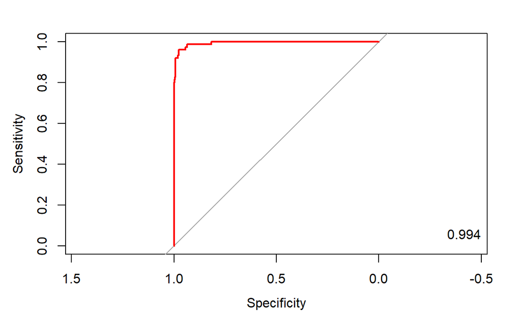

```
pacman::p_load("pROC")

ac     <- UB.ted$Personal.Loan                              # 실제 클래스래스

pp     <- UB.pred.ada$prob[,2]                              # "yes"에 대한 예측 확률 출력

ada.roc <- roc(ac, pp, plot=T, col="red")                   # roc(실제 클래스, 예측 확률)률)

auc <- round(auc(ada.roc), 3)                               # AUC
legend("bottomright",legend=auc, bty="n")
```

```
detach(package:pROC)
```

#### **2) Package “Epi”**

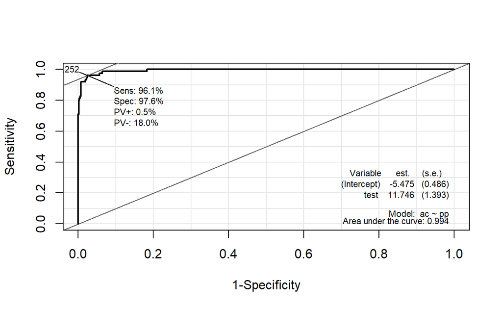

```
# install.packages("Epi")
pacman::p_load("Epi")
# install_version("etm", version = "1.1", repos = "http://cran.us.r-project.org")

ROC(pp,ac, plot="ROC")       # ROC(예측 확률 , 실제 클래스)
```

```
detach(package:Epi)
```

#### **3) Package “ROCR”**

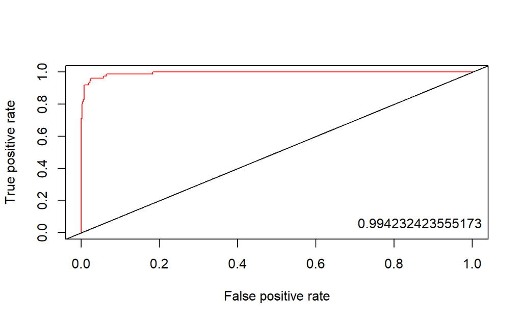

```
pacman::p_load("ROCR")

ada.pred <- prediction(pp, ac)                      # prediction(예측 확률, 실제 클래스)스)

ada.perf <- performance(ada.pred, "tpr", "fpr")     # performance(, "민감도", "1-특이도")
plot(ada.perf, col="red")                           # ROC Curve
abline(0,1, col="black")


perf.auc <- performance(ada.pred, "auc")            # AUC

auc <- attributes(perf.auc)$y.values
legend("bottomright",legend=auc,bty="n")
```

### **향상 차트**

#### **1) Package “ROCR”**

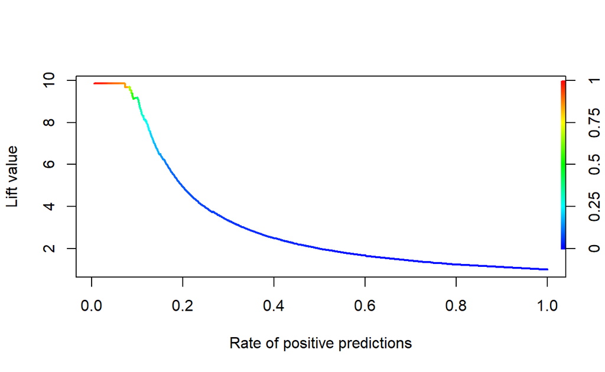

```
ada.lift <- performance(ada.pred,"lift", "rpp")      # Lift chart
plot(ada.lift, colorize=T, lwd=2)
```

```
detach(package:ROCR)
```

#### **2) Package “lift”**

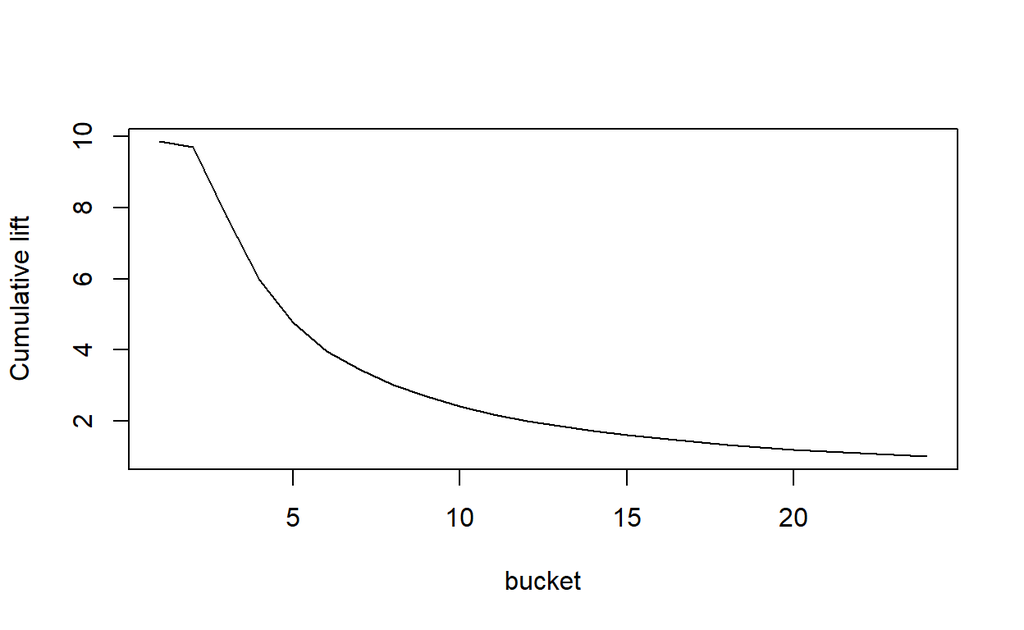

```
# install.packages("lift")
pacman::p_load("lift")

ac.numeric <- ifelse(UB.ted$Personal.Loan=="yes",1,0)     # 실제 클래스를 수치형으로 변환 변환

plotLift(pp, ac.numeric, cumulative = T, n.buckets =24)   # plotLift(예측 확률, 실제 클래스)스)
```

```
TopDecileLift(pp, ac.numeric)                             # Top 10% 향상도 출력
```

```
[1] 9.198
```

```
detach(package:lift)
```

# **4. Gradient Boosting**

> Gradient Boosting은 Boosting에서 가장 많이 쓰이는 방법 중 하나이며, 손실함수가 최소가 되도록하는 값을 예측한다. Gradient Boosting을 수행하기 위하여 Package `"gbm"`을 사용하였다. 자세한 내용은 [여기를 참고한다.](https://www.rdocumentation.org/packages/gbm/versions/2.1.8/topics/gbm)

```
gbm(formula, data, distribution, n.trees, interaction.depth, shrinkage, cv.folds, ...)
```

- `formula` : Target과 예측 변수에 대한 공식으로써 일반적으로 `Target ~ 예측변수` 사용
- `data` : `formula`의 변수들이 있는 데이터 프레임
- `distribution` : Loss Function
- `n.trees` : 생성할 나무 수
- `interaction.depth` : 생성되는 나무의 최대 깊이
- `shrinkage` : Learning Rate
- `cv.folds` : Cross Validation의 Fold 수로, 값을 지정해준다면 모형은 Cross Validation을 수행하며 적합

## **4-1. 모형 적합**

[output not shown]

### **4-1-1. 변수 중요도**

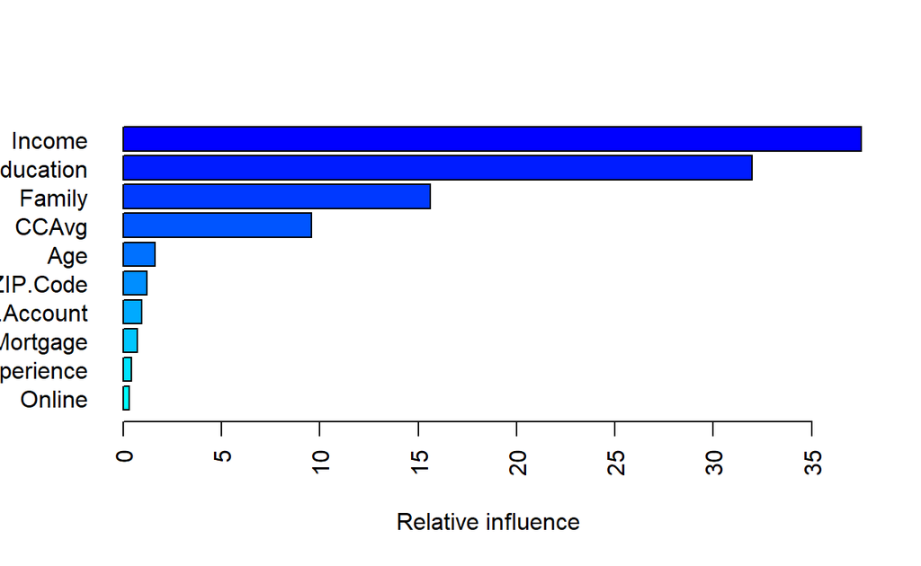

```
                                  var     rel.inf
Income                         Income 37.52364193
Education                   Education 31.98234478
Family                         Family 15.62228585
CCAvg                           CCAvg  9.56978513
Age                               Age  1.61879220
ZIP.Code                     ZIP.Code  1.18463099
CD.Account                 CD.Account  0.95565779
Mortgage                     Mortgage  0.70182276
Experience                 Experience  0.41586694
Online                         Online  0.30314118
CreditCard                 CreditCard  0.06232404
Securities.Account Securities.Account  0.05970641
```

```
# 변수 중요도도
summary(UB.gbm, cBars = 10, las=2)            # cBars : 상위 몇개 나타낼 것인지
```

### **4-1-2. 최적 부스팅 반복 수 찾기**

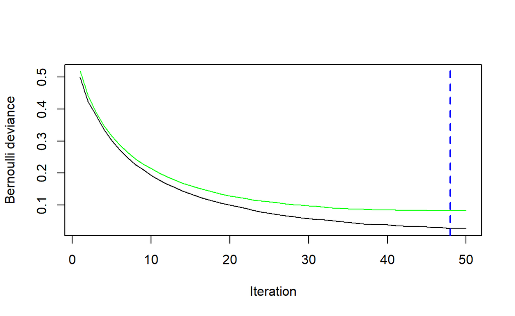

```
ntrees.op <- gbm.perf(UB.gbm, plot.it = T, method="cv")
```

- 검은 선은 Train Error이며, 초록선은 Validation Error이다.

```
ntrees.op
```

```
[1] 48
```

[output not shown]

## **4-2. 모형 평가**

[output not shown]

### **ConfusionMatrix**

```
cv <- 0.5                                                       # cutoff value

pp <- as.factor(ifelse(UB.pred.gbm>cv,"yes","no"))              # 예측 확률>cv이면 "yes" 아니면 "no"
confusionMatrix(pp, UB.ted$Personal.Loan, positive="yes")       # confusionMatrix(예측 클래스, 실제 클래스, positive = "관심 클래스") 클래스")
```

```
Confusion Matrix and Statistics

          Reference
Prediction  no yes
       no  672   9
       yes   1  67

               Accuracy : 0.9866
                 95% CI : (0.9756, 0.9936)
    No Information Rate : 0.8985
    P-Value [Acc > NIR] : < 2e-16

                  Kappa : 0.9232

 Mcnemar's Test P-Value : 0.02686

            Sensitivity : 0.88158
            Specificity : 0.99851
         Pos Pred Value : 0.98529
         Neg Pred Value : 0.98678
             Prevalence : 0.10147
         Detection Rate : 0.08945
   Detection Prevalence : 0.09079
      Balanced Accuracy : 0.94005

       'Positive' Class : yes
```

### **ROC 곡선**

#### **1) Package “pROC”**

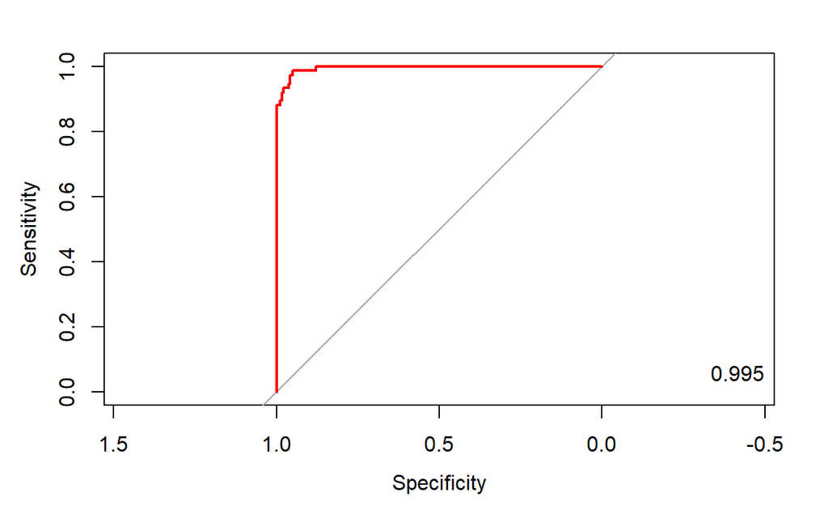

```
pacman::p_load("pROC")

ac     <- UB.ted$Personal.Loan                              # 실제 클래스래스

pp     <- UB.pred.gbm                                       # "1=yes"에 대한 예측 확률 출력

gbm.roc <- roc(ac, pp, plot=T, col="red")                   # roc(실제 클래스, 예측 확률)률)

auc <- round(auc(gbm.roc), 3)                               # AUC
legend("bottomright",legend=auc, bty="n")
```

```
detach(package:pROC)
```

#### **2) Package “Epi”**

[figure not shown]

```
# install.packages("Epi")
pacman::p_load("Epi")
# install_version("etm", version = "1.1", repos = "http://cran.us.r-project.org")

ROC(pp,ac, plot="ROC")       # ROC(예측 확률 , 실제 클래스)
```

```
detach(package:Epi)
```

#### **3) Package “ROCR”**

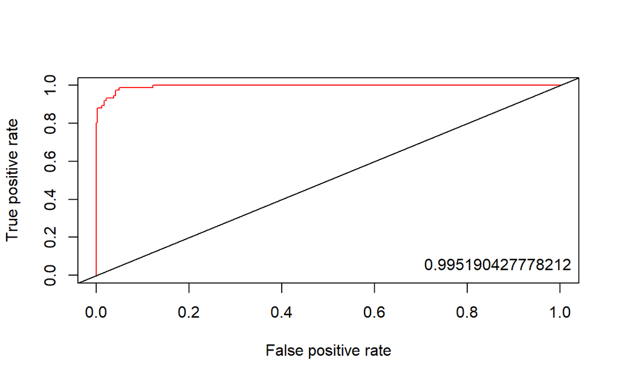

```
pacman::p_load("ROCR")

gbm.pred <- prediction(pp, ac)                      # prediction(예측 확률, 실제 클래스)스)

gbm.perf <- performance(gbm.pred, "tpr", "fpr")     # performance(, "민감도", "1-특이도")
plot(gbm.perf, col="red")                           # ROC Curve
abline(0,1, col="black")


perf.auc <- performance(gbm.pred, "auc")            # AUC

auc <- attributes(perf.auc)$y.values
legend("bottomright",legend=auc,bty="n")
```

### **향상 차트**

#### **1) Package “ROCR”**

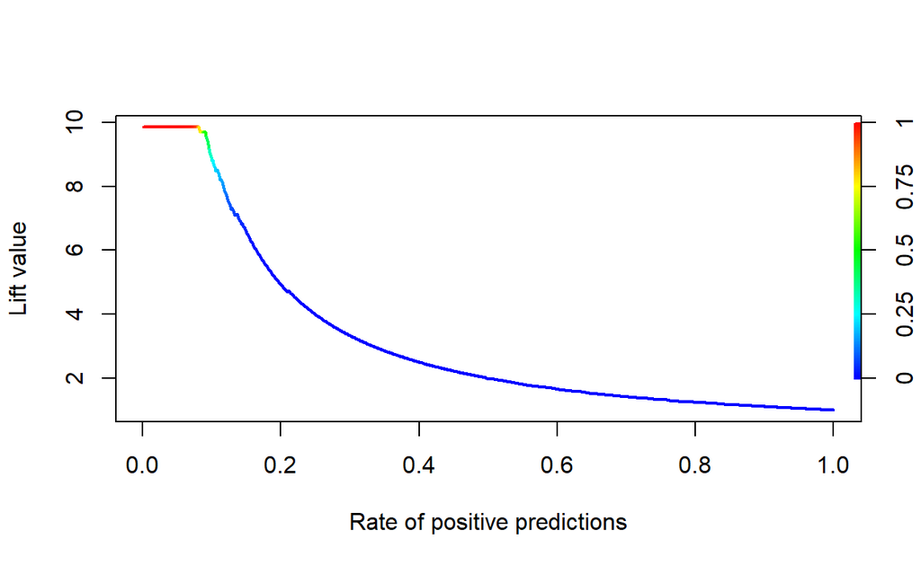

```
gbm.lift <- performance(gbm.pred,"lift", "rpp")      # Lift chart
plot(gbm.lift, colorize=T, lwd=2)
```

```
detach(package:ROCR)
```

#### **2) Package “lift”**

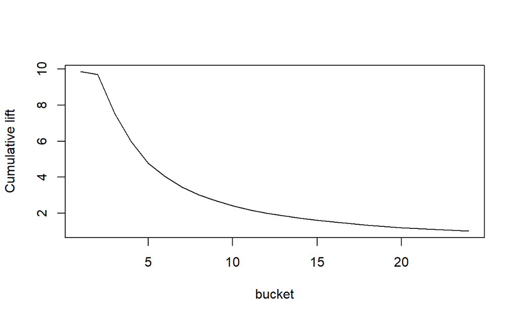

```
# install.packages("lift")
pacman::p_load("lift")

ac.numeric <- ifelse(UB.ted$Personal.Loan=="yes",1,0)     # 실제 클래스를 수치형으로 변환 변환

plotLift(pp, ac.numeric, cumulative = T, n.buckets =24)   # plotLift(예측 확률, 실제 클래스)스)
```

```
TopDecileLift(pp, ac.numeric)                             # Top 10% 향상도 출력
```

```
[1] 8.804
```

```
detach(package:lift)
```

# **5. XGBoost**

> XGBoost는 Extreme Gradient Boosting으로 Gradient Boosting을 기반으로 확장되었다. XGBoost를 수행하기 위해 Package `"xgboost"`를 사용하였다. 자세한 내용은 [여기를 참고한다.](https://www.rdocumentation.org/packages/xgboost/versions/1.2.0.1/topics/xgb.train)

```
xgb.train(params, data, nrounds, watchlist, , ...)
```

- `params` : XGBoost의 Hyperparameter들에 대한 정보가 있는 `List`
- `data` : `xgb.DMatrix` 형태의 dataset
- `nrounds` : 최대 반복 수
- `watchlist` : 모형 성능 평가에 사용할 `xgb.DMatrix` dataset의 이름이 적혀있는 `List`

## **5-1. 모형 적합**

```
pacman::p_load("xgboost",                               # For xgb.train
               "Matrix")                                # For sparse.model.matrix


# XGBoost는 변수가 모두 수치형이어야 함!# sparse.model.matrix : 범주형 변수를 더미변수로 바꿔줌
trainm       <- sparse.model.matrix(Personal.Loan ~. , # Personal.Loan은 Target으로 제외
                                    data=UB.trd)
testm        <- sparse.model.matrix(Personal.Loan ~. , # Personal.Loan은 Target으로 제외
                                    data=UB.ted)

# For xgb.train
train_matrix <- xgb.DMatrix(data=as.matrix(trainm), label=UB.trd$Personal.Loan)
test_matrix  <- xgb.DMatrix(data=as.matrix(testm), label=UB.ted$Personal.Loan)
```

[output not shown]

### **5-1-1. 변수 중요도**

```
# 변수 중요도도
importance <- xgb.importance(feature_names = colnames(trainm), model = UB.xgb)
head(importance)
```

```
      Feature       Gain      Cover  Frequency
1:     Income 0.41051727 0.42115554 0.33107191
2: Education3 0.20465209 0.07438741 0.06784261
3: Education2 0.16415423 0.07938272 0.06784261
4:    Family4 0.09962531 0.05241373 0.06784261
5:    Family3 0.05755740 0.04849138 0.06784261
6:      CCAvg 0.04462385 0.30389002 0.20624152
```

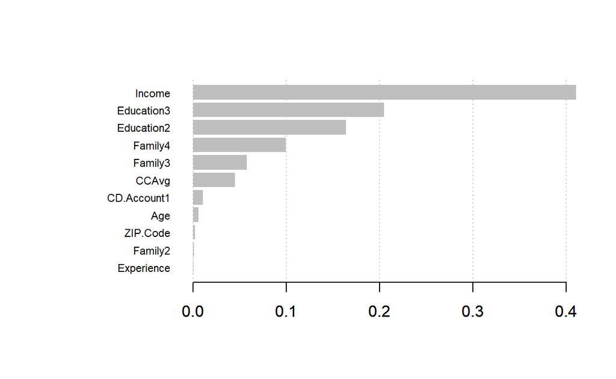

```
xgb.plot.importance(importance_matrix = importance)
```

### **5-1-2. Training Data Error Plot**

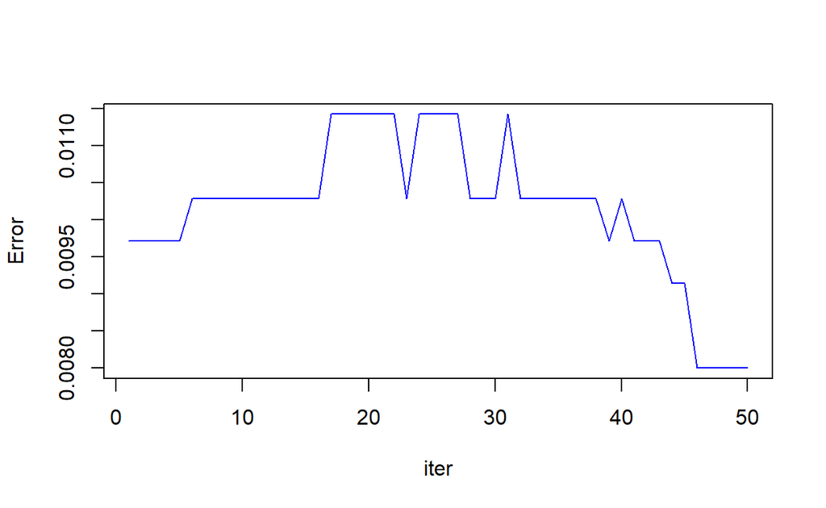

```
plot(UB.xgb$evaluation_log$train_error,
     col="blue", type="l", xlab="iter", ylab="Error")
```

## **5-2. 모형 평가**

[output not shown]

### **ConfusionMatrix**

```
cv <- 0.5                                                       # cutoff value

pp <- as.factor(ifelse(UB.pred.xgb>cv,"yes","no"))              # 예측 확률>cv이면 "yes" 아니면 "no"
confusionMatrix(pp, UB.ted$Personal.Loan, positive="yes")       # confusionMatrix(예측 클래스, 실제 클래스, positive = "관심 클래스") 클래스")
```

```
Confusion Matrix and Statistics

          Reference
Prediction  no yes
       no  664  12
       yes   9  64

               Accuracy : 0.972
                 95% CI : (0.9575, 0.9826)
    No Information Rate : 0.8985
    P-Value [Acc > NIR] : 9.195e-15

                  Kappa : 0.8435

 Mcnemar's Test P-Value : 0.6625

            Sensitivity : 0.84211
            Specificity : 0.98663
         Pos Pred Value : 0.87671
         Neg Pred Value : 0.98225
             Prevalence : 0.10147
         Detection Rate : 0.08545
   Detection Prevalence : 0.09746
      Balanced Accuracy : 0.91437

       'Positive' Class : yes
```

### **ROC 곡선**

#### **1) Package “pROC”**

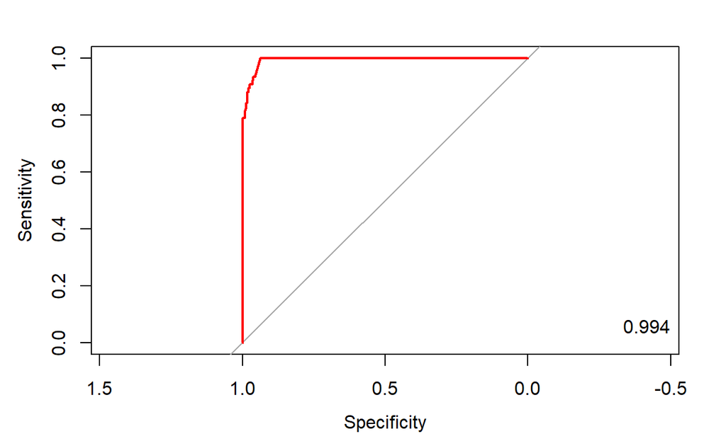

```
pacman::p_load("pROC")

ac     <- UB.ted$Personal.Loan                              # 실제 클래스래스
pp     <- UB.pred.xgb                                       # "1=yes"에 대한 예측 확률 출력

xgb.roc <- roc(ac, pp, plot=T, col="red")                   # roc(실제 클래스, 예측 확률)률)

auc <- round(auc(xgb.roc), 3)                               # AUC
legend("bottomright",legend=auc, bty="n")
```

```
detach(package:pROC)
```

#### **2) Package “Epi”**

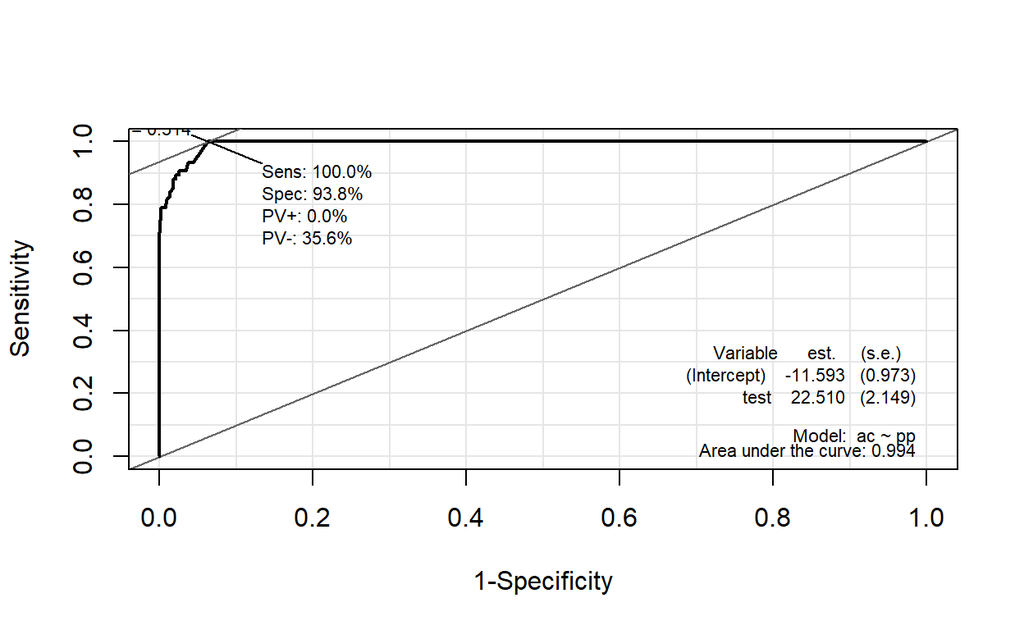

```
# install.packages("Epi")
pacman::p_load("Epi")
# install_version("etm", version = "1.1", repos = "http://cran.us.r-project.org")

ROC(pp,ac, plot="ROC")       # ROC(예측 확률 , 실제 클래스)
```

```
detach(package:Epi)
```

#### **3) Package “ROCR”**

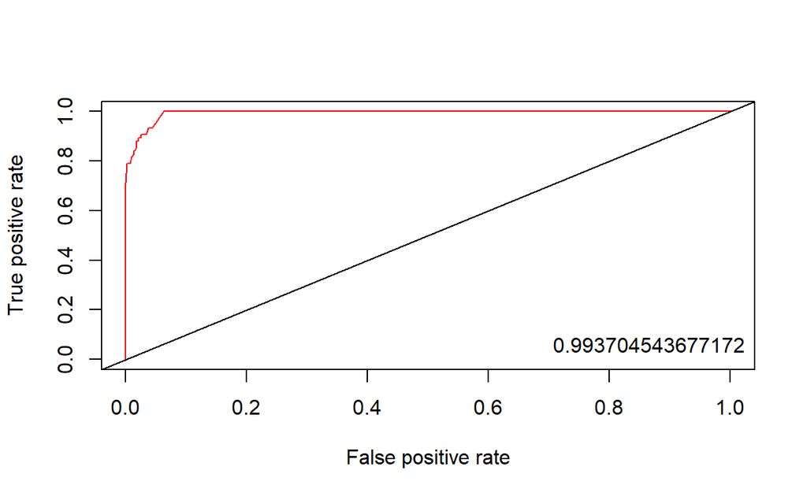

```
pacman::p_load("ROCR")

xgb.pred <- prediction(pp, ac)                      # prediction(예측 확률, 실제 클래스)스)

xgb.perf <- performance(xgb.pred, "tpr", "fpr")     # performance(, "민감도", "1-특이도")
plot(xgb.perf, col="red")                           # ROC Curve
abline(0,1, col="black")


perf.auc <- performance(xgb.pred, "auc")            # AUC

auc <- attributes(perf.auc)$y.values
legend("bottomright",legend=auc,bty="n")
```

### **향상 차트**

#### **1) Package “ROCR”**

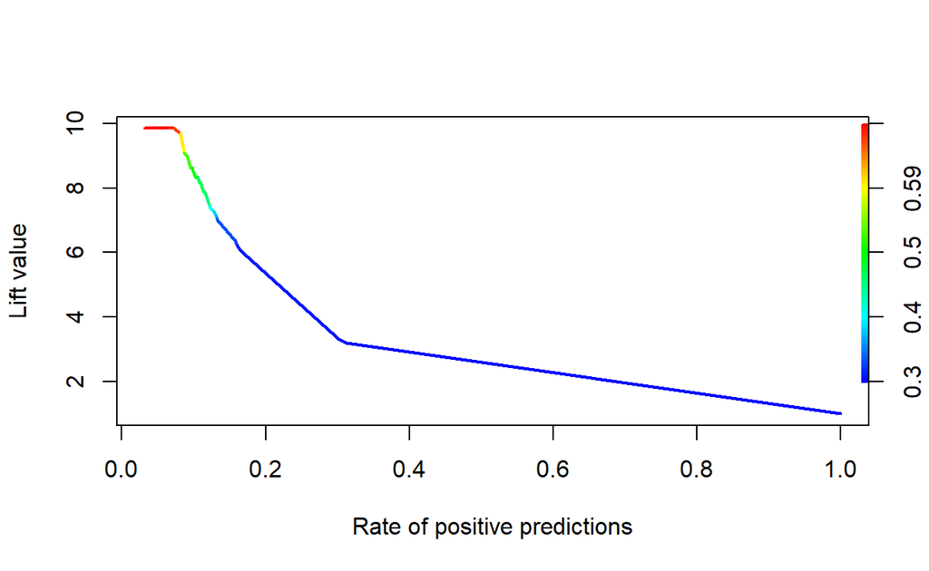

```
xgb.lift <- performance(xgb.pred,"lift", "rpp")      # Lift chart
plot(xgb.lift, colorize=T, lwd=2)
```

```
detach(package:ROCR)
```

#### **2) Package “lift”**

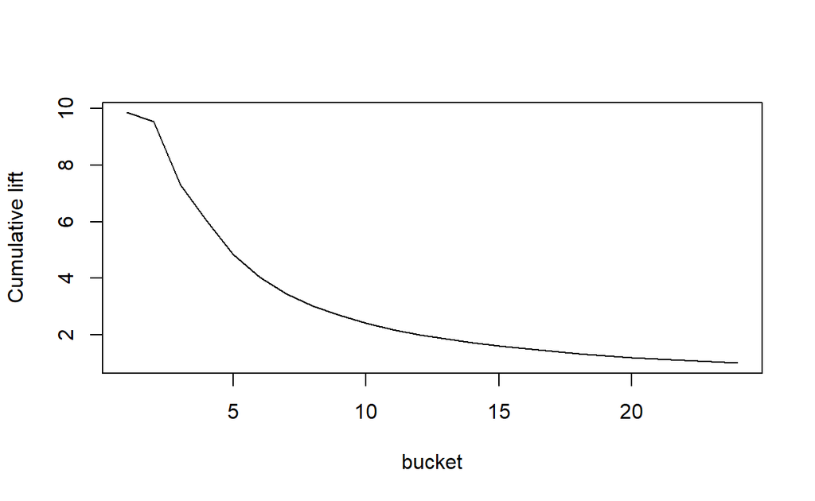

```
# install.packages("lift")
pacman::p_load("lift")

ac.numeric <- ifelse(UB.ted$Personal.Loan=="yes",1,0)     # 실제 클래스를 수치형으로 변환 변환

plotLift(pp, ac.numeric, cumulative = T, n.buckets =24)   # plotLift(예측 확률, 실제 클래스)스)
```

```
TopDecileLift(pp, ac.numeric)                             # Top 10% 향상도 출력
```

```
[1] 8.41
```

```
detach(package:lift)
```

# **6. 모형 비교**

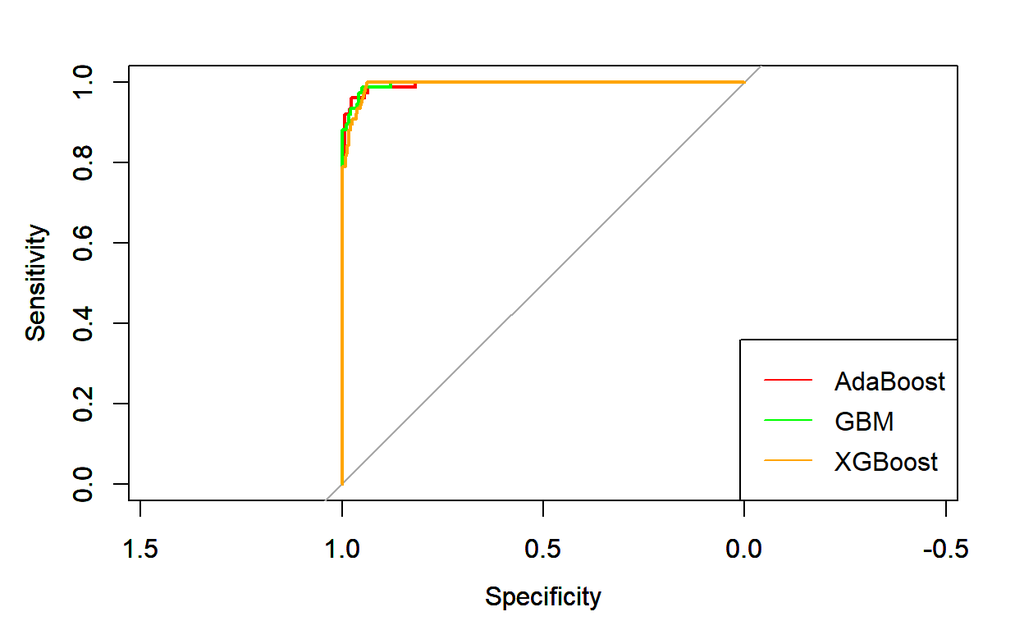

```
plot(ada.roc, col="red")         # ROC Curve
par(new=TRUE)
plot(gbm.roc, col="green")       # ROC Curve
par(new=TRUE)
plot(xgb.roc, col="orange")      # ROC Curve

legend("bottomright", legend=c("AdaBoost", "GBM", "XGBoost" ),
       col=c( "red", "green", "orange"), lty=c(1,1,1))
```